# Planteamiento del Problema

En un mundo alterno existen 3 misioneros y 3 caníbales que se encuentran del lado izquierdo de un río. Todos deben pasar al lado derecho del mismo. Para pasar al otro lado cuentan con un bote. Sin embargo, la capacidad máxima del bote es de dos personas. Es imperativo que en un momento dado no haya más caníbales que misioneros en un lado del río porque se comerían a los misioneros. ¿Cuál sería la estrategia a utilizar para que todas las personas puedan pasar al lado derecho del río sin perder a nadie en el proceso?

# Representación del problema

Se cuenta con un estado inicial llamado matriz el cual es una lista en la que se ha guardo como primer elemento el número de misioneros, caníbales.

```python
from collections import deque
matriz = []
matriz.append([3,3,1])
matriz.append([0,0,0])
```

De igual manera se ha creado un estado final, el cual representa la forma en que deben de terminar nuestro algoritmo.

```python
matrizfinal = []
matrizfinal.append([0,0,0])
matrizfinal.append([3,3,1])
```

Se cuenta con un diccionario llamdo visitados, en el cual se han de ir agregando los estados que ya se han visitado.

```python
visitados={}
visitados[str(matriz)] = True
matriz.append([])
```

# Solución del problema

Se creo una función con la finalidad de validar que el estado generado sea válido evitando que exista mayor número de caníbales que de misioneros en ambos lados del río.

```python
def esvalido(estado):
    x = estado[0] #izquierda
    y = estado[1] #derecha

    if (x[0]>=x[1] and y[0]>=y[1]) or (x[0]==0 and y[0]==3) or (x[0]==3 and y[0]==0):
        return True
    return False
```

Operaciones: hay 5 posibles operaciones que se pueden realizar siempre y cuando cumplan con las limitaciones anteriormente descritas.

OP1: cruzar 1 canibal y 1 misionero OP2: cruzar 2 canibales y 0 misionero OP3: cruzar 0 canibal y 2 misioneros OP4: cruzar 0 canibal y 1 misionero OP5: cruzar 1 canibal y 0 misionero

```python
def misvscan():
    q=deque()
    q.append(matriz)

    while len(q) >0:
        nodo=q.popleft()
        izq=nodo[0]
        der=nodo[1]

        #predecesores se añade al último
        temp = [n for n in nodo[2]]
        temp.append([nodo[0], nodo[1]])
        #Si llega al final
        aux=[izq,der]
        if str(aux)==str(matrizfinal):
            nuevo=[izq,der,temp]
            print("fin")

        if izq[2]==1:#Si el bote está de lado izquierdo

            cantm=izq[0]
            cantc=izq[1]

            if cantm-2>=0:#Dos misioneros al lado derecho se van
                left=[izq[0]-2,izq[1],0]
                right=[der[0]+2,der[1],1]
                nuevo=[left,right]
                if (not str(nuevo) in visitados) and esvalido(nuevo):
                    visitados[str(nuevo)] = True
                    nuevo=[left,right,temp]
                    q.append(nuevo)

            if cantc-2>=0 :#Dos canibales al lado derecho
                left=[izq[0],izq[1]-2,0]
                right=[der[0],der[1]+2,1]
                nuevo=[left,right]
                if (not str(nuevo) in visitados) and esvalido(nuevo):
                    visitados[str(nuevo)] = True
                    nuevo=[left,right,temp]
                    q.append(nuevo)

            if cantm-1>=0 and cantc-1>=0:#Un misionero y un canibal al lado derecho
                left=[izq[0]-1,izq[1]-1,0]
                right=[der[0]+1,der[1]+1,1]
                nuevo=[left,right]
                if (not str(nuevo) in visitados) and esvalido(nuevo):
                    visitados[str(nuevo)] = True
                    nuevo=[left,right,temp]
                    q.append(nuevo)

            if cantm-1>=0:#Un misionero al lado derecho
                left=[izq[0]-1,izq[1],0]
                right=[der[0]+1,der[1],1]
                nuevo=[left,right]
                if (not str(nuevo) in visitados) and esvalido(nuevo):
                    visitados[str(nuevo)] = True
                    nuevo=[left,right,temp]
                    q.append(nuevo)

            if cantc-1>=0:#Un canibal al lado derecho
                left=[izq[0],izq[1]-1,0]
                right=[der[0],der[1]+1,1]
                nuevo=[left,right]
                if (not str(nuevo) in visitados) and esvalido(nuevo):
                    visitados[str(nuevo)] = True
                    nuevo=[left,right,temp]
                    q.append(nuevo)

        else:#Bote del lado derecho

            cantm=der[0]
            cantc=der[1]

            if cantm-2>=0:
                left=[izq[0]+2,izq[1],1]
                right=[der[0]-2,der[1],0]
                nuevo=[left,right]
                if (not str(nuevo) in visitados) and esvalido(nuevo):
                    visitados[str(nuevo)] = True
                    nuevo=[left,right,temp]
                    q.append(nuevo)

            if cantc-2>=0 :#
                left=[izq[0],izq[1]+2,1]
                right=[der[0],der[1]-2,0]
                nuevo=[left,right]
                if (not str(nuevo) in visitados) and esvalido(nuevo):
                    visitados[str(nuevo)] = True
                    nuevo=[left,right,temp]
                    q.append(nuevo)

            if cantm-1>=0 and cantc-1>=0:#
                left=[izq[0]+1,izq[1]+1,1]
                right=[der[0]-1,der[1]-1,0]
                nuevo=[left,right]
                if (not str(nuevo) in visitados) and esvalido(nuevo):
                    visitados[str(nuevo)] = True
                    nuevo=[left,right,temp]
                    q.append(nuevo)

            if cantm-1>=0 :#
                left=[izq[0]+1,izq[1],1]
                right=[der[0]-1,der[1],0]
                nuevo=[left,right]
                if (not str(nuevo) in visitados) and esvalido(nuevo):
                    visitados[str(nuevo)] = True
                    nuevo=[left,right,temp]
                    q.append(nuevo)

            if cantc-1>=0:#
                left=[izq[0],izq[1]+1,1]
                right=[der[0],der[1]-1,0]
                nuevo=[left,right]
                if (not str(nuevo) in visitados) and esvalido(nuevo):
                    visitados[str(nuevo)] = True
                    nuevo=[left,right,temp]
                    q.append(nuevo)
```

# Pruebas

```python
%time
misvscan()
```

```
CPU times: user 5 µs, sys: 1 µs, total: 6 µs
Wall time: 95.4 µs
fin
```

```python
visitados
```

```
{'[[0, 0, 0], [3, 3, 1]]': True,
 '[[0, 1, 0], [3, 2, 1]]': True,
 '[[0, 1, 1], [3, 2, 0]]': True,
 '[[0, 2, 0], [3, 1, 1]]': True,
 '[[0, 2, 1], [3, 1, 0]]': True,
 '[[0, 3, 1], [3, 0, 0]]': True,
 '[[1, 1, 0], [2, 2, 1]]': True,
 '[[1, 1, 1], [2, 2, 0]]': True,
 '[[2, 2, 0], [1, 1, 1]]': True,
 '[[2, 2, 1], [1, 1, 0]]': True,
 '[[3, 0, 0], [0, 3, 1]]': True,
 '[[3, 1, 0], [0, 2, 1]]': True,
 '[[3, 1, 1], [0, 2, 0]]': True,
 '[[3, 2, 0], [0, 1, 1]]': True,
 '[[3, 2, 1], [0, 1, 0]]': True,
 '[[3, 3, 1], [0, 0, 0]]': True}
```

```python
len(visitados)
```

```
16
```

# Representación del problema

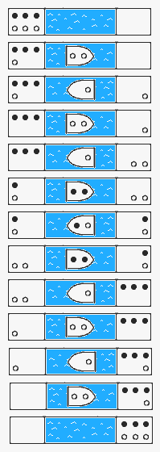

```python
from IPython.display import Image
Image(filename='canibal.png')
```